# Prediction Assignment

Sy

17 August 2018

## Executive Summary

With proliferation of wearable devices, large amount of data about personal activity are collected. This report aims to detect how well these users perform barbell lifts in 5 different ways.A prediction model using these data (accelerometers on the belt, forearm, arm, and dumbell of 6 participants) is created to identify correct and incorrect ways of performing barbell lifts.

## Methodology

Two models are created and compared to identify the best prediction model in terms of prediction accuracy. The method chosen are decision tree and random forest.

## Load required library

```r
suppressWarnings(library(caret))
suppressWarnings(library(rattle))
suppressWarnings(library(randomForest))
suppressWarnings(library(corrplot))
suppressWarnings(library(e1071))
suppressWarnings(library(nnet))
suppressWarnings(library(rpart))
suppressWarnings(library(rpart.plot))
```

## Loading data - Human Activity Recognition

These data are provided by Groupware@Les

```r
url1 <- "https://d396qusza40orc.cloudfront.net/predmachlearn/pml-training.csv"
url2 <- "https://d396qusza40orc.cloudfront.net/predmachlearn/pml-testing.csv"

download.file(url1, destfile = "./train.csv")
download.file(url2, destfile = "./test.csv")

train <- read.csv("./train.csv")
test <- read.csv("./test.csv")
```

## Preparation of Data for Modeling

70% of the data will be randomly selected as training dataset and remaining 30% will be testing dataset.

```r
inTrain <- createDataPartition(train$classe, p = 0.7, list = FALSE)
training <- train[inTrain,]
testing <- train[-inTrain,]
```

Features with near zero variance, NA with more than 90% will be removed, and non-predictors (identification columns)

```r
## remove near zero variance features
nzv <- nearZeroVar(training)
training <- training[,-nzv]
testing <- testing[, -nzv]

## remove features with high missing values
na <- sapply(training, function(x) mean(is.na(x))) >0.90
training <- training[, na == FALSE]
testing <- testing[, na == FALSE]

## remove non-predictors from data
training <- training[, -(1:5)]
testing <- testing[, -(1:5)]

dim(training); dim(testing)
```

```
## [1] 13737    54
```

```
## [1] 5885   54
```

## Exploratory Data Analysis

Identify features which are highly correlated with one another and remove them from the analysis.

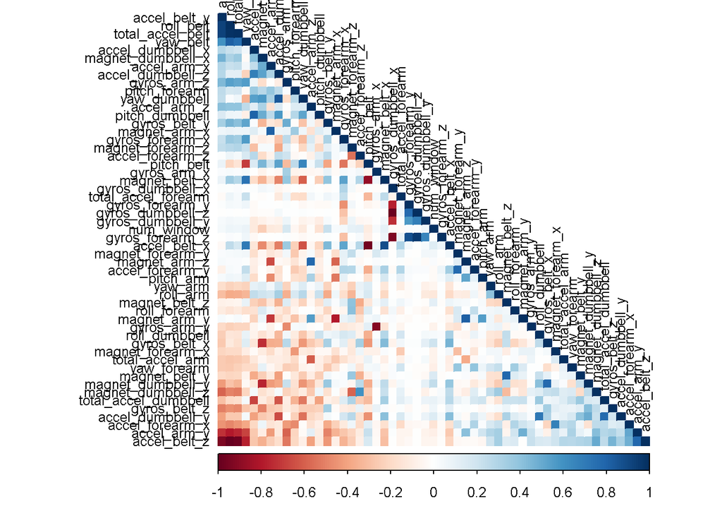

```r
matrix <- cor(training[, -54])
corrplot(matrix, order = "FPC", method = "color", type = "lower", tl.cex = 0.8, tl.col = rgb(0, 0, 0))
```

Since most of the features are not correlated to one another and our features are already reduced to 53, there is no need for feature reduction techniques such as PCA.

## Prediction Modeling

### Decision Tree

[figure not shown]

```r
set.seed(123)
dtfit <- rpart(classe ~., data =training, method = "class")
rpart.plot(dtfit)
```

```r
# prediction on test data
preddt <- predict(dtfit, newdata = testing, type = "class")
confdt <- confusionMatrix(preddt, testing$classe)
dtacc <- round(confdt$overall['Accuracy']*100,digits = 2)
dtacc
```

```
## Accuracy
##    74.07
```

```r
confdt
```

```
## Confusion Matrix and Statistics
##
##           Reference
## Prediction    A    B    C    D    E
##          A 1514  214   43   78   68
##          B   53  674   66   83  117
##          C    8   62  837  145   67
##          D   77  150   59  624  120
##          E   22   39   21   34  710
##
## Overall Statistics
##
##                Accuracy : 0.7407
##                  95% CI : (0.7293, 0.7519)
##     No Information Rate : 0.2845
##     P-Value [Acc > NIR] : < 2.2e-16
##
##                   Kappa : 0.6705
##  Mcnemar's Test P-Value : < 2.2e-16
##
## Statistics by Class:
##
##                      Class: A Class: B Class: C Class: D Class: E
## Sensitivity            0.9044   0.5917   0.8158   0.6473   0.6562
## Specificity            0.9043   0.9328   0.9420   0.9175   0.9758
## Pos Pred Value         0.7898   0.6788   0.7480   0.6058   0.8596
## Neg Pred Value         0.9597   0.9049   0.9603   0.9300   0.9265
## Prevalence             0.2845   0.1935   0.1743   0.1638   0.1839
## Detection Rate         0.2573   0.1145   0.1422   0.1060   0.1206
## Detection Prevalence   0.3257   0.1687   0.1901   0.1750   0.1404
## Balanced Accuracy      0.9044   0.7623   0.8789   0.7824   0.8160
```

```r
#confdt$table
#plot(confdt$table, main = "Confusion Matrix of Decision Tree")
```

The model is able to predict fairly well with 74.07% accuracy.

### Random Forest

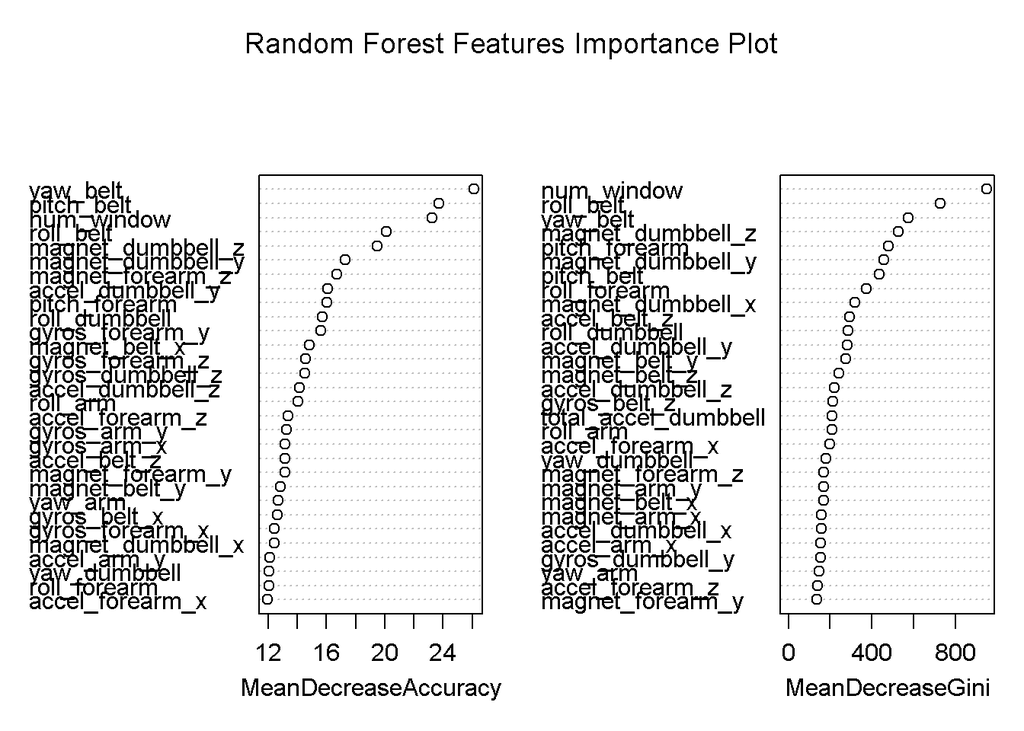

```r
set.seed(123)
n <- 100 #number of trees
rffit <- randomForest(classe ~., data = training, importance=TRUE, ntree= n)
varImpPlot(rffit, main = "Random Forest Features Importance Plot")
```

```r
# prediction on test data
predrf <- predict(rffit, newdata = testing, type = "class")
confrf <- confusionMatrix(predrf, testing$classe)
rfacc <- round(confrf$overall['Accuracy']*100,digits = 2)
rfacc
```

```
## Accuracy
##    99.56
```

```r
confrf
```

```
## Confusion Matrix and Statistics
##
##           Reference
## Prediction    A    B    C    D    E
##          A 1674    0    0    0    0
##          B    0 1137    5    0    0
##          C    0    2 1020   14    0
##          D    0    0    1  950    4
##          E    0    0    0    0 1078
##
## Overall Statistics
##
##                Accuracy : 0.9956
##                  95% CI : (0.9935, 0.9971)
##     No Information Rate : 0.2845
##     P-Value [Acc > NIR] : < 2.2e-16
##
##                   Kappa : 0.9944
##  Mcnemar's Test P-Value : NA
##
## Statistics by Class:
##
##                      Class: A Class: B Class: C Class: D Class: E
## Sensitivity            1.0000   0.9982   0.9942   0.9855   0.9963
## Specificity            1.0000   0.9989   0.9967   0.9990   1.0000
## Pos Pred Value         1.0000   0.9956   0.9846   0.9948   1.0000
## Neg Pred Value         1.0000   0.9996   0.9988   0.9972   0.9992
## Prevalence             0.2845   0.1935   0.1743   0.1638   0.1839
## Detection Rate         0.2845   0.1932   0.1733   0.1614   0.1832
## Detection Prevalence   0.2845   0.1941   0.1760   0.1623   0.1832
## Balanced Accuracy      1.0000   0.9986   0.9954   0.9922   0.9982
```

```r
#plot(confrf$table, main = "Confusion Matrix of Random Forest")
```

The model is able to predict with high accuracy of 99.56%.

## Model Comparison

From above, random forest exhibits the highest prediction accuracy (99.56%) and will be used for the quiz tests.

```r
predtest <- predict(rffit, newdata = test)
predtest
```

```
##  1  2  3  4  5  6  7  8  9 10 11 12 13 14 15 16 17 18 19 20
##  B  A  B  A  A  E  D  B  A  A  B  C  B  A  E  E  A  B  B  B
## Levels: A B C D E
```